# BIKE CASE STUDY

By Maria Fernanda GARIBAY

https://github.com/mariagaribay2025

## Introduction

The dataset features bike rental data with different variables tracked. The study uncovers specific user behavior patterns that result from daily activities combined with weather patterns. Accurate alignment of operational decisions with real demand depends on understanding these patterns. Research from similar bike‑sharing studies demonstrates how commuting patterns and weather conditions are key considerations. Results‑focused will be presented to executives to find practical insights and strategic advice. The goal of this analysis is to find key factors influencing rental demand such as time of day, day of the week, temperature, and rain.

```python
# importing packages
import pandas as pd             # Data science essentials
import matplotlib.pyplot as plt # Data visualization essentials
import seaborn as sns           # Enhanced data visualization
import numpy as np

# suppressing user warnings
import warnings                 # warnings
warnings.simplefilter(action='ignore', category=UserWarning)

# specifying a file name
file = 'bikes_data.xlsx'

# converting data types with a dictionary
data_types = {
    "Month"       : str,
    "Day of Week" : str,
    "Season"      : str,
    "Holiday"     : str
}

# reading the file into Python through pandas
bike = bikes = pd.read_excel(io = 'bikes_data.xlsx'     ,
                     sheet_name = 0      ,
                     header     = 0      ,
                     dtype      = data_types)

# outputting the first 5 rows of the dataset
bike.head(n = 5)
```

|  | ID | Month | Day of Week | Hour | Temperature | Humidity | Wind Speed | Visibility | Dew Point Temperature | UV Index | Rainfall | Snowfall | Season | Holiday | RENTALS |
| --- | --- | --- | --- | --- | --- | --- | --- | --- | --- | --- | --- | --- | --- | --- | --- |
| 0 | 1 | Jan | Sunday | 0 | -3.2 | 40 | 0.5 | 1358 | -14.9 | 0.00 | 0.0 | 0.0 | Winter | Yes | 221 |
| 1 | 2 | Jan | Sunday | 13 | 2.4 | 22 | 2.3 | 1921 | -17.2 | 1.10 | 0.0 | 0.0 | Winter | Yes | 268 |
| 2 | 3 | Jan | Sunday | 16 | 3.0 | 28 | 2.5 | 1864 | -13.7 | 0.51 | 0.0 | 0.0 | Winter | Yes | 335 |
| 3 | 4 | Jan | Sunday | 17 | 1.8 | 33 | 3.3 | 1913 | -12.8 | 0.18 | 0.0 | 0.0 | Winter | Yes | 299 |
| 4 | 5 | Jan | Sunday | 20 | -0.3 | 40 | 1.2 | 1936 | -12.2 | 0.00 | 0.0 | 0.0 | Winter | Yes | 225 |

```python
# revise information from dataset
bike.info()
```

```
<class 'pandas.core.frame.DataFrame'>
RangeIndex: 1387 entries, 0 to 1386
Data columns (total 15 columns):
 #   Column                 Non-Null Count  Dtype
---  ------                 --------------  -----
 0   ID                     1387 non-null   int64
 1   Month                  1387 non-null   object
 2   Day of Week            1387 non-null   object
 3   Hour                   1387 non-null   int64
 4   Temperature            1387 non-null   float64
 5   Humidity               1387 non-null   int64
 6   Wind Speed             1387 non-null   float64
 7   Visibility             1387 non-null   int64
 8   Dew Point Temperature  1387 non-null   float64
 9   UV Index               1387 non-null   float64
 10  Rainfall               1387 non-null   float64
 11  Snowfall               1387 non-null   float64
 12  Season                 1387 non-null   object
 13  Holiday                1387 non-null   object
 14  RENTALS                1387 non-null   int64
dtypes: float64(6), int64(5), object(4)
memory usage: 162.7+ KB
```

```python
# linear correlation between numeric columns (Pearson Method)
bike.iloc[ : , 1: ].corr(method = 'pearson', numeric_only = True).round(decimals = 2)
```

|  | Hour | Temperature | Humidity | Wind Speed | Visibility | Dew Point Temperature | UV Index | Rainfall | Snowfall | RENTALS |
| --- | --- | --- | --- | --- | --- | --- | --- | --- | --- | --- |
| Hour | 1.00 | 0.11 | -0.25 | 0.27 | 0.15 | -0.01 | 0.14 | 0.02 | -0.06 | 0.42 |
| Temperature | 0.11 | 1.00 | 0.17 | -0.04 | 0.06 | 0.91 | 0.34 | 0.05 | -0.25 | 0.55 |
| Humidity | -0.25 | 0.17 | 1.00 | -0.33 | -0.54 | 0.55 | -0.47 | 0.19 | 0.11 | -0.22 |
| Wind Speed | 0.27 | -0.04 | -0.33 | 1.00 | 0.17 | -0.17 | 0.31 | -0.02 | -0.01 | 0.12 |
| Visibility | 0.15 | 0.06 | -0.54 | 0.17 | 1.00 | -0.16 | 0.17 | -0.12 | -0.08 | 0.24 |
| Dew Point Temperature | -0.01 | 0.91 | 0.55 | -0.17 | -0.16 | 1.00 | 0.08 | 0.11 | -0.17 | 0.38 |
| UV Index | 0.14 | 0.34 | -0.47 | 0.31 | 0.17 | 0.08 | 1.00 | -0.06 | -0.08 | 0.25 |
| Rainfall | 0.02 | 0.05 | 0.19 | -0.02 | -0.12 | 0.11 | -0.06 | 1.00 | 0.00 | -0.11 |
| Snowfall | -0.06 | -0.25 | 0.11 | -0.01 | -0.08 | -0.17 | -0.08 | 0.00 | 1.00 | -0.16 |
| RENTALS | 0.42 | 0.55 | -0.22 | 0.12 | 0.24 | 0.38 | 0.25 | -0.11 | -0.16 | 1.00 |

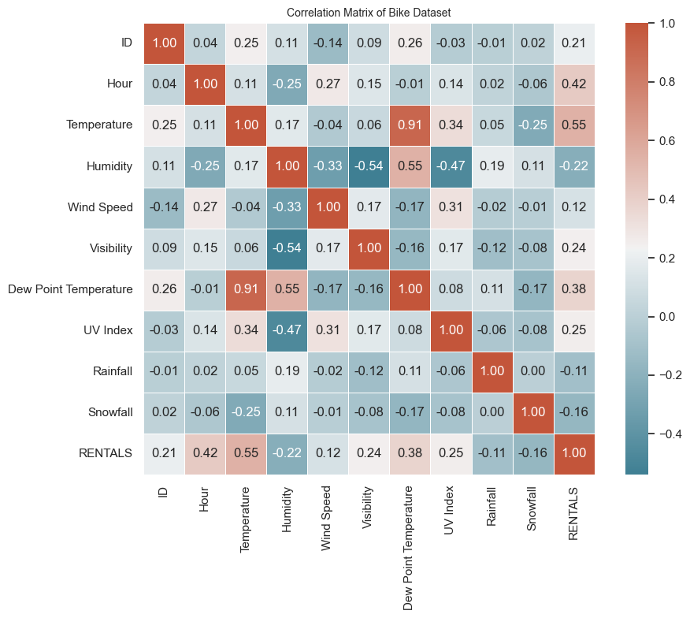

```python
# load dataset
bike = pd.read_excel('bikes_data.xlsx')

# compute correlation matrix using only numeric columns
corr_df = bike.select_dtypes(include='number').corr()

# set heatmap size and style
plt.figure(figsize=(10, 8))
sns.set(style='white')

# plot heatmap
custom_cmap = sns.diverging_palette(220, 20, as_cmap=True)
sns.heatmap(corr_df, annot=True, fmt=".2f", cmap=custom_cmap, linewidths=0.5, square=True)

# add title to heatmap
plt.title('Correlation Matrix of Bike Dataset', fontsize=10)
plt.tight_layout()

# displaying heatmap
plt.show(block = True)
```

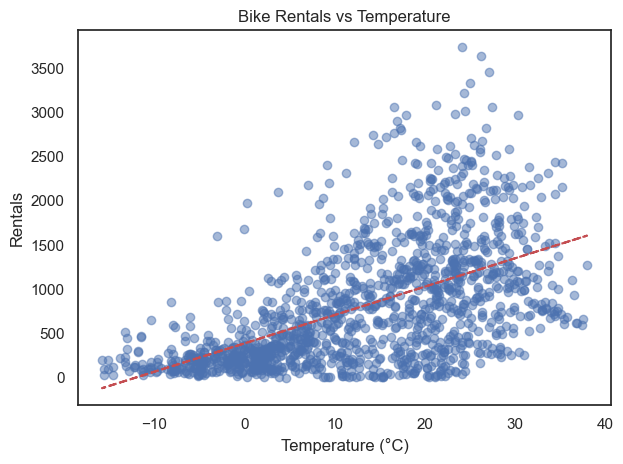

```python
# scatter plot: Rentals vs Temperature
plt.figure()
plt.scatter(bike['Temperature'], bike['RENTALS'], alpha=0.5)
z = np.polyfit(bike['Temperature'], bike['RENTALS'], 1)

# create the polynomial equation
p = np.poly1d(z)

# displaying scatter plot
plt.plot(bike['Temperature'], p(bike['Temperature']), "r--")
plt.xlabel('Temperature (°C)')
plt.ylabel('Rentals')
plt.title('Bike Rentals vs Temperature')
plt.tight_layout()
plt.show()
```

## Bike Rentals vs Temperature

This scatter plot shows a positive relation between ambient temperature and rental volume: Rental counts increase when temperatures fall between 20 and 30 °C. The use of bicycles declines significantly when temperatures fall below 0 °C demonstrating strong sensitivity to rider comfort. The wide range of rental activity during warm temperatures demonstrates that most riders handle moderate heat well but rental numbers decrease during extreme hot weather. Marketing teams can optimize promotion timing on days expected to reach temperatures between 24–29 °C by understanding the thermal sweet spot. The system enables synchronization with weather forecasts to adjust inventory logistics based on expected increases in demand during moderate weather and to reduce stock during extreme conditions.

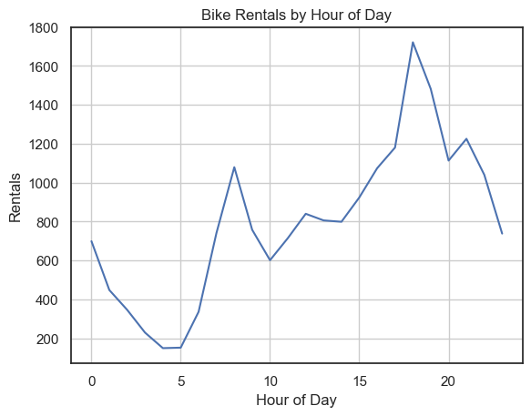

```python
# Plot average rentals by hour of day
hourly = bike.groupby('Hour')['RENTALS'].mean()

# Now plot
import matplotlib.pyplot as plt

# displaying plot
plt.figure()
plt.plot(hourly.index, hourly.values)
plt.xlabel('Hour of Day')
plt.ylabel('Rentals')
plt.title('Bike Rentals by Hour of Day')
plt.grid(True)
plt.show()
```

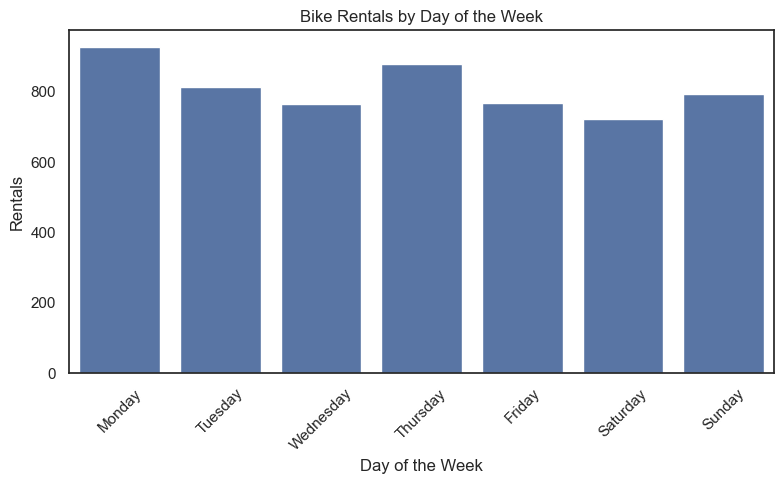

```python
# calculating average rentals by Days of the Week
weekday_rentals = bike.groupby(by = 'Day of Week').agg({'RENTALS': 'mean'})

# reordering days manually
weekday_order = ['Monday', 'Tuesday', 'Wednesday', 'Thursday', 'Friday', 'Saturday', 'Sunday']
weekday_rentals = weekday_rentals.reindex(weekday_order)

# setting figure size
plt.figure(figsize = (8, 5))

# barplot of average Days of the Week
sns.barplot(x     = weekday_rentals.index,
            y     = weekday_rentals.RENTALS)

# Plot Days of the Week
plt.title(label   = "Bike Rentals by Day of the Week")
plt.xlabel(xlabel = "Day of the Week")
plt.ylabel(ylabel = "Rentals")
plt.xticks(rotation = 45)

# displaying the plot
plt.tight_layout()
plt.show()
```

## Bike Rentals by Hour of Day and Days of Week

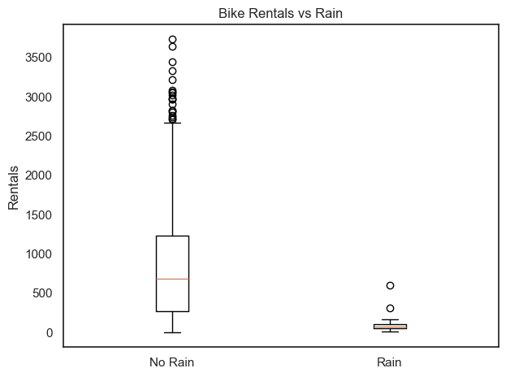

```python
# Example assuming 'Rain' is a column where 1 = Rain and 0 = No Rain
rentals_no_rain = bike[bike['Rainfall'] == 0]['RENTALS']
rentals_rain = bike[bike['Rainfall'] == 1]['RENTALS']

# Boxplot: No Rain vs Rain
plt.figure()
plt.boxplot([rentals_no_rain, rentals_rain], labels=['No Rain', 'Rain'])
plt.ylabel('Rentals')
plt.title('Bike Rentals vs Rain')
plt.tight_layout()
plt.show()
```

## Bike Rentals Distribution: No Rain vs Rain

The boxplot comparison drives home the dramatic impact of precipitation: The median number of rentals reaches over 650 on dry days but drops below 100 during rainy hours. Rain events create a significant deterrent effect as outlier volume during rainy periods seldom comes close to typical dry‑day levels. The drop in usage during rainy periods could be reduced by running tests on promotional strategies such as rain‑guarantee refund programs. The data visualization confirms that precipitation information must be integrated into all operational and marketing decisions.

## Analysis Questions

**1. What motivates most users to rent bicycles from the system?**

Bicycle rentals match weekday schedules and reach their highest points during morning (8 AM) and evening (6 PM) peak traffic times because most trips appear to serve commuting purposes rather than recreational activities. The increased average weekday volume (≈831) versus weekend volume (≈758) demonstrates that most regular users use the service for commuting to work. The commuter focus of the users shows their preference for economical and time-saving travel options compared to traditional driving or public transit for connecting the first and last mile of their journeys.

**2. Which weather conditions lead to peak bike rental demand?**

The highest rental demand happens during bright days with mild weather when temperatures range from 24 °C to 29 °C and humidity levels stay between 30% and 60% without any rainfall. The average number of rentals reaches beyond 1,350 per hour under these conditions which represents almost twice the system's full-time average. The occurrence of rain or snow leads to a significant demand drop as hourly averages decline below 200. While light to moderate wind speeds are generally acceptable despite only displaying a weak positive correlation they become problematic when strong gusts occur which could deter usage.

**3. What strategic approach should the company implement in light of these findings?**

Incorporate short‑term weather predictions to ensure bikes are moved to areas of high demand before favorable weather conditions appear. Marketing strategies should target casual riders with special offers for day-passes and discounted subscriptions on days anticipated to be ideal for biking. Utilizing dynamic pricing methods like peak-time surge discounts helps to regulate demand and optimize bike system usage. Collaborations between public transit authorities and weather‑app providers allow companies to create specific promotions for regular commuters and riders sensitive to weather conditions.

### Top Three Insights

1. **Rides increase during weekdays and rush hours when commuters drive demand**

   A strong positive correlation exists between rental rates and ambient temperature. The highest average bike rental numbers occur between 24 to 29 °C with rates above 1,350 bikes per hour while rainy or snowy days experience average rental numbers dropping below 200 bikes per hour which shows an 80% decrease in demand. Station‑level weather impacts the bike share usage surges during clear and mild weather conditions
3. **Proactive, Data‑Driven Operations = Competitive Advantage**

   Responding to real-time weather changes by linking demand predictions enables dynamic rebalancing along with promotional strategies that include discounted evening rates on less popular days to unlock hidden demand. Combining efforts with transit organizations and mobile weather services helps to reach more people while delivering personalized messages for specific user groups.

## Conclusion

The analysis reveals bicycle sharing functions as a commuter service experiencing peak activity during weekday rush hours. The demand for bicycle rentals is primarily influenced by weather conditions since clear and mild days generate peak rentals while precipitation leads to major declines. The results provide a strategic guide to use weather forecasts alongside dynamic pricing and specific marketing efforts to increase ridership levels. The company will be able to boost user satisfaction and system performance by synchronizing its operational strategies with established temporal patterns and environmental sensitivities. The service will stay responsive to daily commuter patterns and changing weather conditions through ongoing monitoring and regular updates.

## Citations

Wadhwani, P. (2024, March). E-City/Urban Bike Market Size - By Battery (Lithium-Ion, SLA, NiMH), By Motor (Mid Motor, Hub Motor), By Sales Channel (Offline, Online), By Propulsion Type (Pedal, Throttle) & Forecast, 2024 - 2032. Global Market Insights Inc. https://www.gminsights.com/industry-analysis/e-city-urban-bike-market

Gueseloff, L. (2024, November 27). The global bicycle market is an ever-evolving industry shaped by sustainability goals, urban mobility demands, and a growing interest in health and fitness. In 2023, the market was valued at approximately $65 billion, with forecasts projecting a compound annual growth rate (CAGR) of 6. Linkedin.com. https://www.linkedin.com/pulse/global-bicycle-market-trends-opportunities-investment-lucas-gueseloff-taume/

OpenAI. (2024). ChatGPT (Feb 4 Version) [Large language model]. https://openai.com